### Relative abundance Deep-water Corals

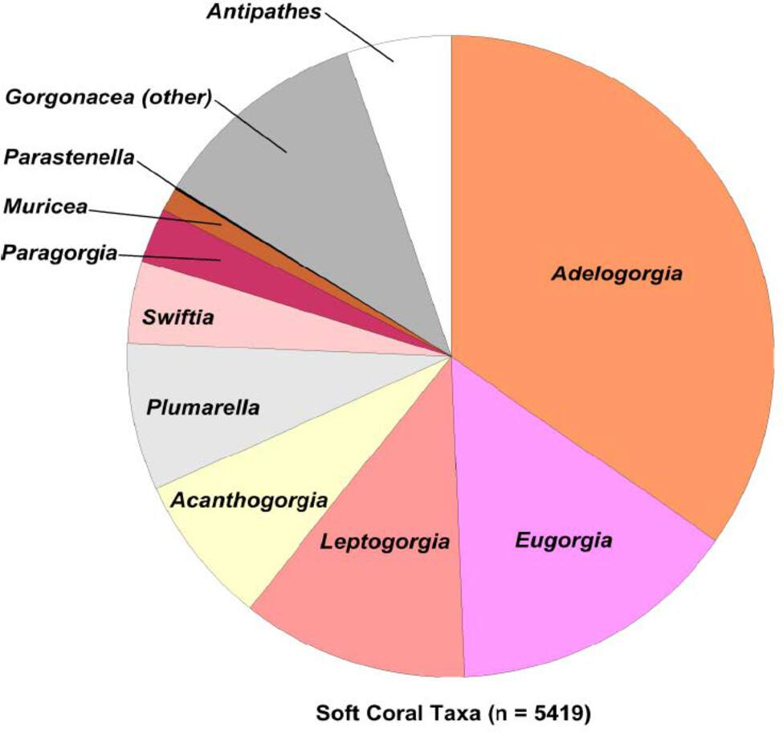

**Figure App.E.10.26.**. A pie chart showing the number of deep-water soft corals observed in the Southern California Bight. Organisms are grouped by genus.

**Click for Details**

The breakdown for the number of deep-water soft corals colonies observed in each genus for the Southern California Bight. Among the 34,792 images collected by the SWFSC Sebastes ROV between 2003 and 2011 throughout the entire Southern California Bight, researchers observed a total of 5,419 colonies. Adelogorgia was most common with 1,832 colonies in 535 observations. *Eugorgia* was second most common with 792 colonies in 436 observations. Figure: Etnoyer et al. 2015

### Condition of Gorgonian Corals

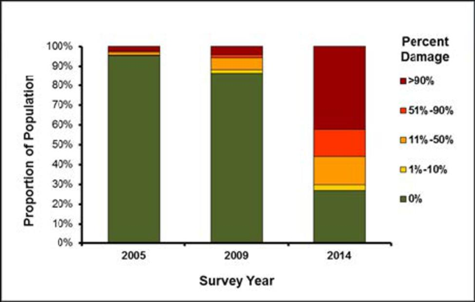

**Figure App.E.10.28.**. A figure showing different levels of damage on gorgonians on Anacapa Island as seen during remotely-operated-vehicle surveys (2005, 2009, and 2014).

**Click for Details**

Percent of gorgonians showing different levels damage at Anacapa Island during ROV surveys in 2005, 2009, and 2014. By 2014, less than 30 percent of observed gorgonians at Anacapa Island had no recognizable damage. Interactions with fishing gear and increasing water temperatures are thought to contribute to the increases in observed gorgonian damage at Anacapa Island. Gorgonian populations at more western islands are thought to fare better compared to Anacapa due to cooler water and less fishing effort. Figure: [MARE](https://www.maregroup.org/)